# AMS6001_ProjectConsolidation

### 3.5 Naive Bayes Method

#### 3.5.0 Further Data-preprocessing

```r
library(klaR)
```

#### 3.5.0.0 Fail attempt with cross-validation

```r
#train_index <- createFolds(train_data_k$output, k = 10)
#NBayesFit00 <- train_data_k %>% train(output ~ .,
#method = "nb",
#data = .,
#tuneLength = 10,
#trControl = trainControl(method = "cv", indexOut = train_index) #restecg2, caa4 got too few data
#)
#NBayesFit00
```

##### Fail because: restecg2, caa4 got too few data

#### 3.5.0.0.0 Fail attempt without cross-validation and ALL predictor

```r
#NBayesFit000 <- train_data_k %>% train(output ~ .,
#method = "nb",
#data = .
#)
#NBayesFit000
```

##### Fail becuase: many observations can’t do resampling properly, warning about thall1 is also seen.

#### 3.5.1 Trial using all predictors BUT those problem-levels

```r
train_data_k_n <- train_data_k
test_data_k_n <- test_data_k
col_to_be_dropped <- c("restecg", "caa", "thall")
col_remained <- setdiff(names(train_data_k_n), col_to_be_dropped)
train_data_k_n <- train_data_k_n[col_remained]
test_data_k_n <- test_data_k_n[col_remained]

train_data_k_n <- na.omit(train_data_k_n)
levels(train_data_k_n$output) <- c("NH", "H")
levels(test_data_k_n$output) <- c("NH", "H")
```

##### output ‘0’ and ‘1’ are renamed as ‘NH’ and ‘H’ respectively

##### (denoted “NO heart attack” and “Heart attack” respectively)

```r
suppressMessages({ suppressWarnings({
NBayesFit <- train_data_k_n %>% train(output ~ .,
method = "nb",
data = .,
trControl = trainControl(
    method = "cv", # used for configuring resampling method: in this case cross validation
    number = 10,
    index = createFolds(train_data_k_n$output, k = 10),
    #summaryFunction = twoClassSummary,
    classProbs = TRUE,
    verboseIter = FALSE,
    savePredictions = TRUE
  ),
tuneLength = 10,
tuneGrid = expand.grid(
    fL = 1:5,
    usekernel = c(TRUE, FALSE),
    adjust = 1:3
  )
)
})})
```

##### our tuning grid consider three components:

##### [usekernel] we try both GUASSIAN and NON-GUASSIAN DISTRIBUTION of output

##### [fL] should be Laplace creation parameter to deal with zero probability in the middle, we let the programme try 1 to 5 and advise the best

##### [adjust] is the brandwidth adjustment. We try 1 to 3 and expect 2. Align with the actual distribution of the output (2 peaks).

```r
NBayesFit
```

```
## Naive Bayes
##
## 257 samples
##  10 predictor
##   2 classes: 'NH', 'H'
##
## No pre-processing
## Resampling: Cross-Validated (10 fold)
## Summary of sample sizes: 25, 25, 26, 26, 26, 25, ...
## Resampling results across tuning parameters:
##
##   fL  usekernel  adjust  Accuracy   Kappa
##   1   FALSE      1       0.7532468  0.5041238
##   1   FALSE      2       0.7532468  0.5041238
##   1   FALSE      3       0.7532468  0.5041238
```

[output cut: 31 more lines]

```r
#Accuracy, Kappa and ROC Plot
suppressMessages({ suppressWarnings({
  predictions <- predict(NBayesFit, newdata = test_data_k_n)
}) })
confusionMatrix(predictions, test_data_k_n$output)$overall["Accuracy"]
```

```
## Accuracy
## 0.826087
```

```r
confusionMatrix(predictions, test_data_k_n$output)$overall["Kappa"]
```

```
##     Kappa
## 0.6275304
```

```r
library(pROC)
```

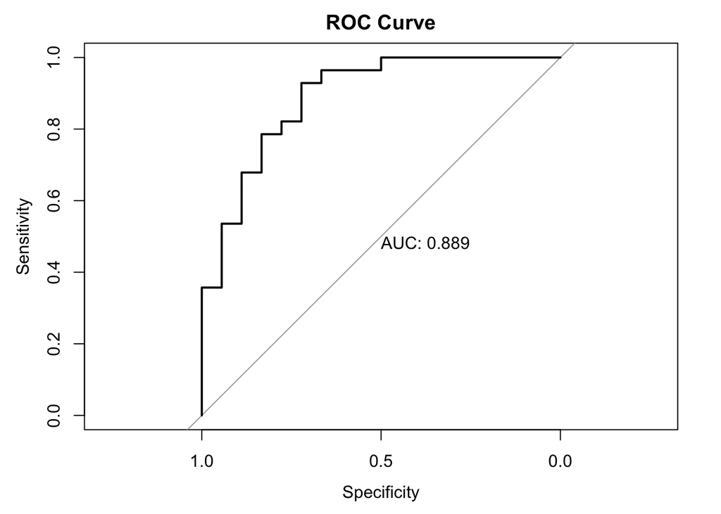

```r
suppressMessages({ suppressWarnings({
roc_curve <- roc(test_data_k_n$output, predict(NBayesFit, newdata = test_data_k_n, type = "prob")$H)
plot(roc_curve, main = "ROC Curve", print.auc = TRUE)
}) })
```